# Assignment 2: Two competing species

Note to Pablo: I gave rMarkdown a try but for some reason I can’t download to PDF. Maybe you can take a look in the office.

## 1. Stability of one-species equilibirum

*In examining the dimensionless Lotka-Volterra competition model in class, we saw that for* $u^∗_1 = 1, u^∗_2 = 0$ *to be stable, we needed* $\alpha_{21} > 1$. *Interpret and justify this result.* *Would your conclusions be affected if you learned that* $\alpha_{12}$ *were extremely large?*

$\alpha_{21}$ is the effect of species 1 on species 2. If it is smaller than 1, that means that the presence of species 1 will allow for more growth in species 2 when it invades. This means the equilibrium of only species 1 is unstable. This is still true when $\alpha_{12}$, the effect of species 2 on species one is large. Because this effect is negative, it would even speed up the replacement of species 1.

## 2. Invasion Analysis

$$\left. \frac{dN_1}{dt}\right. |_{N_1=0,N_2=N_2^*}>0$$
We look at the equation for $\frac{dN_1}{dt}$ when $N_1$ is very very small
$$\frac{dN_1}{dt}= r_1N_1(1-\frac{N_1}{K_1}-b_{1,2}\frac{N^*_2}{K_1})$$
$rN_1$ is going to be very small but positive when $N_1$ invades so we search for an expression where $(1-\frac{N_1}{K_1}-b_{1,2}\frac{N_2}{K_1})>0$. Since $\frac{N_1}{K_1}$ is very small, everything depends on $b_{1,2}\frac{N_2^*}{K_1}<1$. This is the case when $b_{1,2}N_2^*<K_1$. Put biologically, the negative effect of species 2 on species 1 at species 2’s equilibrium $b_{1,2}N_2$ needs to be smaller than the carrying capacity of $K_1$. This makes sense intuitively since in order to invade while $N_2$ is at equilibirum there needs to be some empty space in the niche that $N_1$ would occupy and part of which it shares with $N_2$. This ties in with the traditional few of competition as a description of the niche overlap of two species. The term $b_{1,2}\frac{N_2^*}{K_1}$ is the same as $a_{1,2}$ in our substitution. Comparing invasibility analysis to stability analysis, we see they are very similar, both setting one species to its equilibirum and introducing change in the other. The difference is that invasibility always means the second species starts at 0, while stability analysis can mean the other species can be at any equilibrium and undergo a small change in population.

## 3. Equilibria and their Stability

$$\frac{dx}{dt}=x(24-x-2y)$$
$$\frac{dy}{dt} = y(30-y-2x)$$
We solve to find the equilibria:
$$\begin{cases}
x^*= 0 \\
y^*= 0
\end{cases}
\begin{cases}
x^*= 0 \\
y^*= 30
\end{cases}\begin{cases}
x^*= 24 \\
y^*= 0
\end{cases}
\begin{cases}
x^*= 12 \\
y^*= 6
\end{cases}$$
We can see that of the four equilibria only $x^*= 12 y^*= 6$ is feasible since $x>0$ and $y>0$. Next we evaluate all four points for stability using the Jacobian matrix of the system.
$$\mathbf{J} =
\begin{bmatrix}
\displaystyle \frac{\partial f_1}{\partial u_1} & \displaystyle \frac{\partial f_1}{\partial u_2}\\
\displaystyle \frac{\partial f_2}{\partial u_1} & \displaystyle \frac{\partial f_2}{\partial u_2}
\end{bmatrix} =
\begin{bmatrix}
24-2x-2y & -2x \\
-2y & 30-2y-2x
\end{bmatrix}$$
From here we check whether $Det(\mathbf{J})>0$ and $Tr(\mathbf{J})<0$ for each potential eqilibrium.

For $x^*=y^*=0$
$$\mathbf{A} =
\begin{bmatrix}
24 & 0 \\
0 & 30
\end{bmatrix}$$
Thus the characteristic polynomial is
$$(24-\lambda)(30-\lambda) \rightarrow \lambda_1 = 30, \lambda_2 =24$$

This means $Tr(\mathbf{A})>0$ and the equilibrium is unstable (remember $Tr(\mathbf{J})=\lambda_1+\lambda_2)$,$Det(\mathbf{J}) =\lambda_1\times\lambda_2$)

To classify our three equilibria, we can look at the Eigenvalues. Any point where the Eigenvalues have opposite signs is a saddle point, so this is the case when for the fourth equilibirum when $x^*= 12$ and $y^*= 6$.Depending on which direction the system is perturbed in, it will drive one of the species to extinction. For the other three equilibria, $Det(\mathbf{A})>0$ and the Eigenvalues are real with the same sign. This means all three are nodes. We can see the dynamics in the plot below.

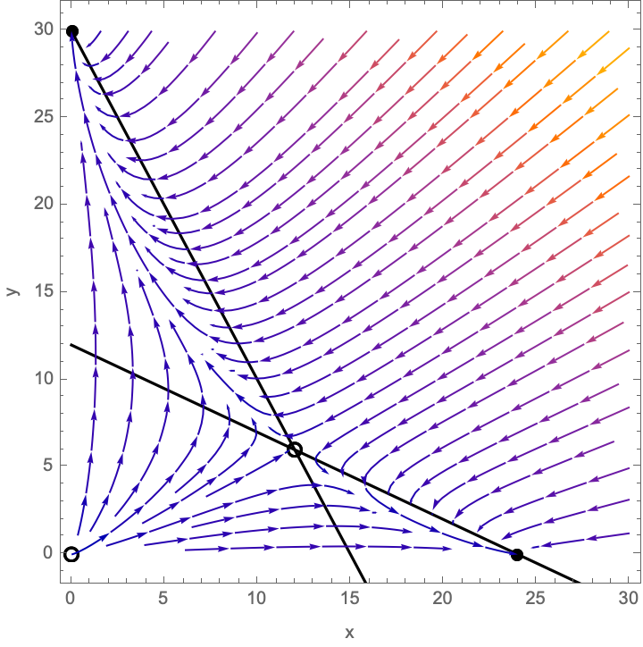

Plot 1: the dynamics of the system shows the four equilibrium points

Code for the plot in Mathematica: Show[{Plot[{(24 - x)/2, -2 (-15 + x)}, {x, 0, 30}, PlotStyle -> Black, Frame -> True, FrameLabel -> {“x”, “y”}], ListPlot[List /@ {{0, 0}, {0, 30}, {24, 0}, {12, 6}}, PlotStyle -> Directive[Black, PointSize[Large]], PlotMarkers -> {{Graphics[Circle[]], Medium}, None, None, {Graphics[Circle[]], Medium}}], StreamPlot[{x (24 - x - 2 y), y (30 - y - 2 x)}, {x, 0, 30}, {y, 0, 30}]}, PlotRange -> {{0, 30}, {0, 30}}, AspectRatio -> 1]